# the motivating use-case for simeta::

## 0.1 preamble

```r
library(simeta)
library(varameta)

# other packages used in this vignette
library(tidyverse)
library(skimr)

# otherwise i'll forget
conflicted::conflict_prefer("filter", winner = "dplyr")

# for reproducibility
set.seed(39)
```

# 1 Objective of the `simeta::` package

The `simeta::` package aims to provide coverage probability simulation results for estimators derived, as is common in meta-analyses, from summary statistics for the variance of the sample median.

Different simulation-level parameters of interest can be specified so that simulated data mimics different meta-analytic conditions:

- Different numbers of $K$ studies.
- Different values of $\tau^2$, the variation between the studies.
- Different distributions.
- Different distributions of expected sample sizes.
- Different proportions of control and intervention group.

The components of the algorithm have been produced in a compartmentalised way, with the objective of exploring the extendability of this package to estimators for the variance of the sample mean, but also for estimators for the mean or median, themselves.

In this vignette, we restrict ourselves to the original use-case of the package, testing estimators for the variance of the sample median.

# 2 Using `simeta::` to assess an estimator for the sample median

Taking a case study in the meta-analysis of medians, using estimators provided by `varameta::`, we outline the problem, and use the `simeta::` package to assess the estimators.

## 2.1 A case study

In this analysis, we are interested in assessing how an estimator for the variance of the sample median performs in under various meta-analytic conditions.

We will test estimators provided by `varameta::` package.

For example, given a sample median of 50, an interquartile range of 0.6, and a sample size of 24, how do we estiamte the variance of the sample median?

```r
# estimate this using varameta::
effect_se(
  centre = 50,
  spread = 0.6,
  n = 24,
  centre_type = "median",
  spread_type = "iqr")
```

```
## [1] 0.1137883
```

How can we tell if this is a *good* estimator for the variance of the sample median?

## 2.2 Assessing the estimator

The `metasims` function is a wrapper function that takes in a trial function.

```r
# metasims function with default arguments
sims <-
  metasims(
    single_study = FALSE,
    measure = "median",
    measure_spread = "iqr",
    distributions = default_parameters,
    k = c(3, 7, 10),
    tau_sq_true = seq(from = 0, to = 0.4, by = 0.2),
    unequal_effect_ratio = 1.2,
    min_n = 20,
    max_n = 200,
    prop = 0.5,
    prop_error = 0.1,
    trials = params$trials,
    trial_fn = metatrial,
    beep = FALSE,
    knha = TRUE,
    progress = FALSE
  )

# take a look at results
sims %>% pluck("results") %>% head()
```

```
## # A tibble: 6 x 20
##   measure  tau_sq ci_width     bias coverage_count successful_tria… coverage id    errors warnings messages
##   <chr>     <dbl>    <dbl>    <dbl>          <int>            <int>    <dbl> <chr>  <int>    <int>    <int>
## 1 lr_med… 0.00528    0.261 -0.0284               2                3    0.667 sim_1      0        0        3
## 2 median  0.0110     0.532  0.00541              3                3    1     sim_1      0        0        3
## 3 lr_med… 0.0863     1.82  -0.0181               3                3    1     sim_2      0        0        3
## 4 median  0.00388    0.384 -0.00228              3                3    1     sim_2      0        0        3
## 5 lr_med… 0.00709    1.35   0.0331               3                3    1     sim_3      0        0        3
## 6 median  0.0250     0.944 -0.0194               2                3    0.667 sim_3      0        0        3
## # … with 9 more variables: result <int>, k <dbl>, tau_sq_true <dbl>, effect_ratio <chr>, rdist <chr>,
## #   parameters <list>, n <list>, true_effect <dbl>, sim_results <list>
```

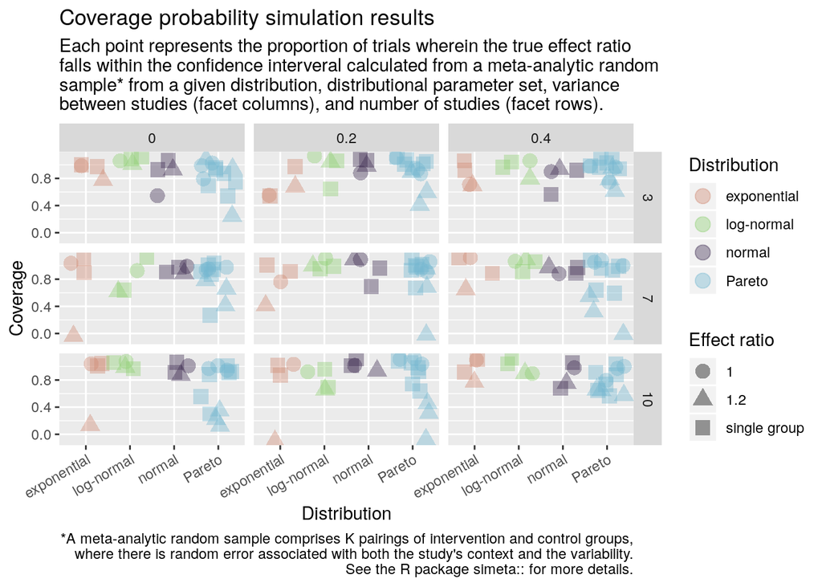

```r
# basic scatterplot
sims %>%
  coverage_plot()
```

# 3 Components of simeta

The central motivation to modularising this package is attempting to address how to create extendable research analyses. Perhaps not all of the solutions provided are of use, but perhaps some components are.

In this section we describe the different classes of functions in the `simeta::` package. These fall into roughly three categories. Simulation-level parameters set the different parameters to simulate over, such as number of studies or true effect ratio. Research output tools provide outputs of the analysis for reporting, with tables and visualisations. Finally, simulation tools, where the components of `simeta::` have been modularised for use and extendability in other analyses.

## 3.1 Simulation-level parameters

The `metasims` function has a set of default simulation-level parameters, `default_parameters`. In the following section it is shown how to specify these parameters.

```r
# arguments are easier to read and extract using the output of the simulation object
sims %>%
  pluck("arguments") %>%
    kableExtra::kable() %>%
  kableExtra::kable_styling()
```

| argument | value |
| --- | --- |
| single_study | FALSE |
| measure | median |
| measure_spread | iqr |
| distributions | default_parameters |
| k | c(3, 7, 10) |
| tau_sq_true | seq(from = 0, to = 0.4, by = 0.2) |
| unequal_effect_ratio | 1.2 |
| min_n | 20 |
| max_n | 200 |
| prop | 0.5 |
| prop_error | 0.1 |
| trials | params$trials |
| trial_fn | metatrial |
| beep | FALSE |
| knha | TRUE |
| progress | FALSE |

```r
# this simulation used the same as the default arguments
```

In the above table, we set simulation-level parameters: distribution sets, `distributions`; number of studies, `k`; true variation between the studies, `tau_sq_true`; unequal effect ratio, `unequal_effect_ratio`, in addition to testing for no effect; minimum, `min_n`, and maximum, `max_n`, expected sample sizes with proportion, `prop`, and associated error, `prop_err`; and number of trials, `trials`, of each simulation.

The distributions sampled are expected to be in the form of a table, with one column for distributions `dist` in an R-friendly format, and parameters `par` in a list.

```r
# simeta comes with a default parameter set
default_parameters %>%
  kableExtra::kable() %>%
  kableExtra::kable_styling()
```

| dist | par |
| --- | --- |
| norm | list(mean = 2, sd = 0.3) |
| exp | list(rate = 2) |
| pareto | list(shape = 3, scale = 3) |
| pareto | list(shape = 2, scale = 1) |
| pareto | list(shape = 0.5, scale = 1) |
| lnorm | list(meanlog = 1, sdlog = 0.3) |

### 3.1.1 Specifying distribution parameters

It is expected to be of the form of a `tibble` with a column, `dist`, for R-friendly distribution names and a column, `par`. R-friendly means by concatenating on `d`, `p`, `q`, or `r`, you obtain a distribution function in R.

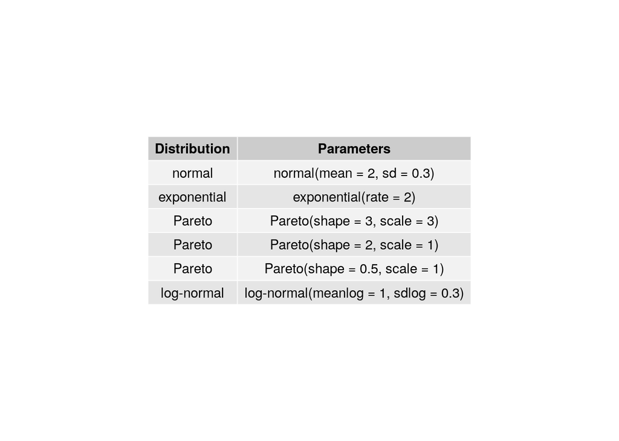

```r
sims %>%
  pluck("distributions") %>%
  sim_dist(output = "table")
```

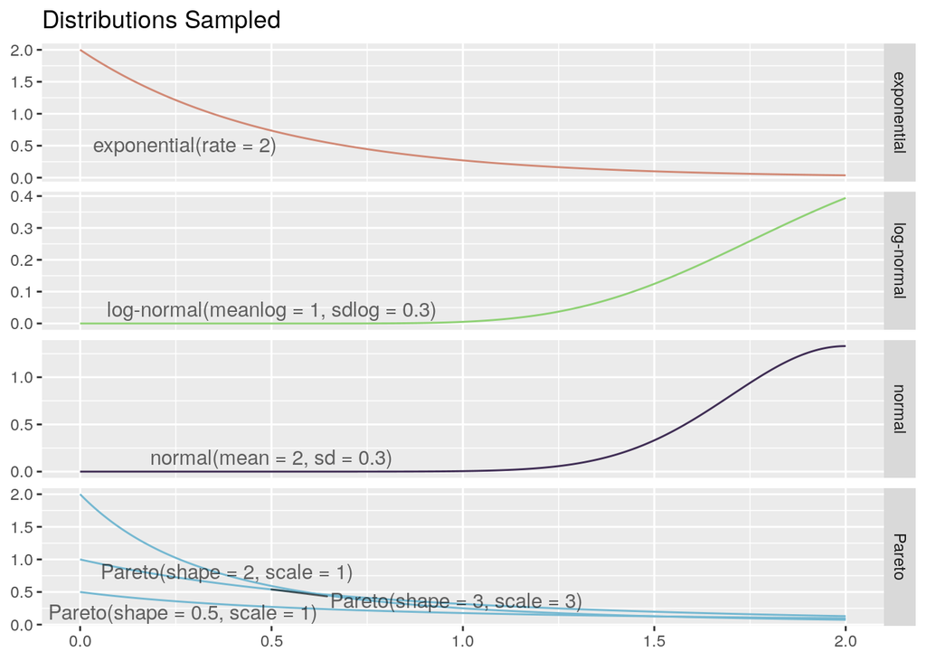

```r
sims %>%
  pluck("distributions") %>%
  sim_dist()
```

The `simeta::` package is currently coded to simulate date from the normal, exponential, Pareto, and log-normal distributions.

The mathematical methodology to is repeated, but the derivation is slightly different.

For these distributions, any reasonable parameter choice can be specified via the `par` column.

## 3.2 Research output tools

Simeta provides a few research outputs, which we describe in this section:

1. Coverage plot
2. Distributions sampled summary tools
3. Simulation results as data

### 3.2.1 Coverage plot

The coverage probability plot produced by `coverage_plot` summarises the proportion of trials for each metaparameter set of distribution, variation between studies, effect ratio, and number of studies.

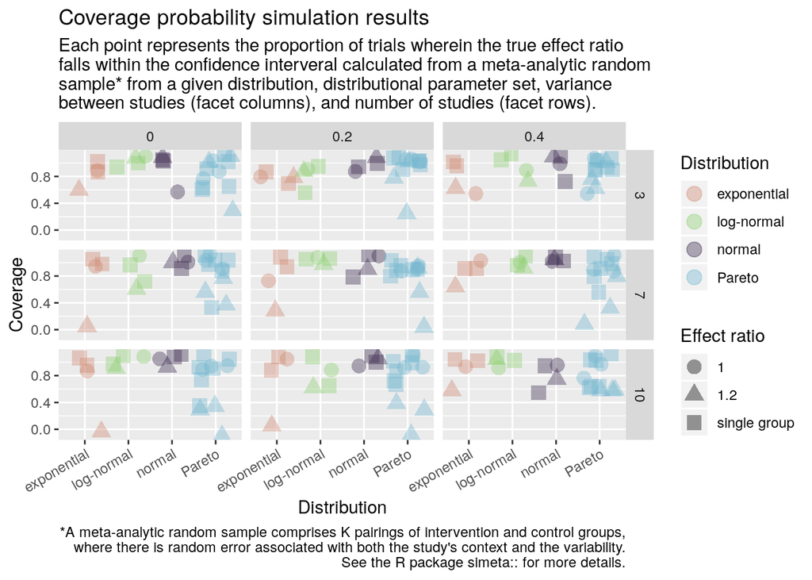

```r
sims %>%
  coverage_plot()
```

### 3.2.2 Distributions summary

There are three ways to summarise the distributions sampled in the simulation:

1. Plot
2. Table
3. R dataframe

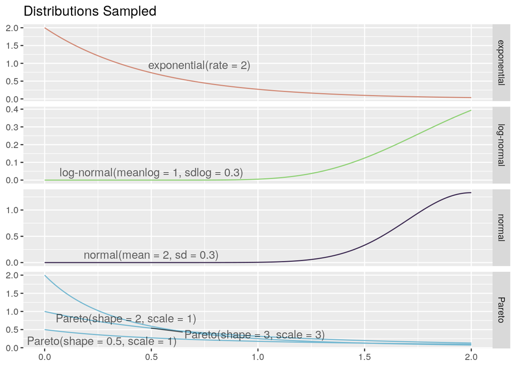

```r
# plot
sims %>%
  pluck("distributions") %>%
  sim_dist()
```

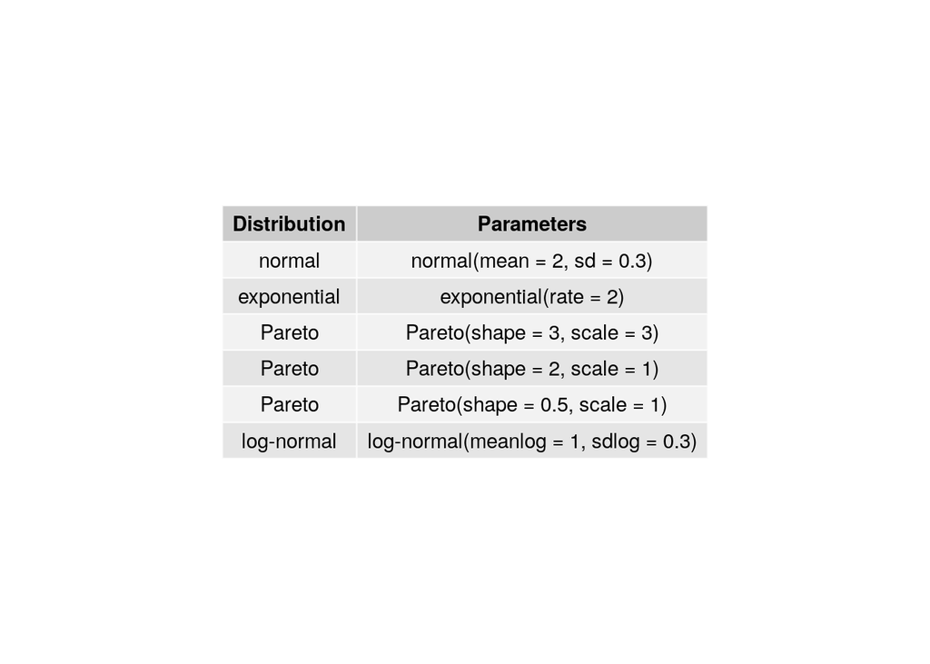

```r
# table
sims %>%
  pluck("distributions") %>%
  sim_dist(output = "table")
```

```r
# data.frame
sims %>%
  pluck("distributions")
```

```
##     dist      par
## 1   norm 2.0, 0.3
## 2    exp        2
## 3 pareto     3, 3
## 4 pareto     2, 1
## 5 pareto 0.5, 1.0
## 6  lnorm 1.0, 0.3
```

### 3.2.3 Simulation results

A list-object is returned from `metasims` that provides:

1. simulation results in a tibble
2. simulation metaparameters in a summary tibble
3. simulation metaparameters, one row per simulation
4. simulation distributions

```r
# metasims-created object
sims %>% str(1)
```

```
## List of 4
##  $ results      :Classes 'tbl_df', 'tbl' and 'data.frame':   216 obs. of  20 variables:
##  $ arguments    :Classes 'tbl_df', 'tbl' and 'data.frame':   16 obs. of  2 variables:
##  $ sim_pars     :Classes 'tbl_df', 'tbl' and 'data.frame':   108 obs. of  8 variables:
##  $ distributions:Classes 'distributions' and 'data.frame':   6 obs. of  2 variables:
##  - attr(*, "class")= chr [1:2] "sim_ma" "list"
```

```r
# simulation results
sims %>% pluck("results") %>% skimr::skim()
```

Data summary

| Name | Piped data |
| --- | --- |
| Number of rows | 216 |
| Number of columns | 20 |
| _______________________ |  |
| Column type frequency: |  |
| character | 4 |
| list | 3 |
| numeric | 13 |
| ________________________ |  |
| Group variables | None |

**Variable type: character**

| skim_variable | n_missing | complete_rate | min | max | empty | n_unique | whitespace |
| --- | --- | --- | --- | --- | --- | --- | --- |
| measure | 0 | 1.0 | 6 | 9 | 0 | 2 | 0 |
| id | 0 | 1.0 | 5 | 7 | 0 | 108 | 0 |
| effect_ratio | 108 | 0.5 | 8 | 8 | 0 | 2 | 0 |
| rdist | 0 | 1.0 | 3 | 6 | 0 | 4 | 0 |

**Variable type: list**

| skim_variable | n_missing | complete_rate | n_unique | min_length | max_length |
| --- | --- | --- | --- | --- | --- |
| parameters | 0 | 1 | 6 | 1 | 2 |
| n | 0 | 1 | 108 | 3 | 3 |
| sim_results | 0 | 1 | 108 | 12 | 12 |

**Variable type: numeric**

| skim_variable | n_missing | complete_rate | mean | sd | p0 | p25 | p50 | p75 | p100 | hist |
| --- | --- | --- | --- | --- | --- | --- | --- | --- | --- | --- |
| tau_sq | 0 | 1 | 0.10 | 0.18 | 0.00 | 0.00 | 0.03 | 0.13 | 1.34 | ▇▁▁▁▁ |
| ci_width | 0 | 1 | 0.88 | 1.00 | 0.05 | 0.29 | 0.61 | 1.03 | 7.13 | ▇▁▁▁▁ |
| bias | 0 | 1 | -0.10 | 0.22 | -1.01 | -0.17 | -0.02 | 0.02 | 0.31 | ▁▁▂▇▂ |
| coverage_count | 0 | 1 | 2.59 | 0.73 | 0.00 | 2.00 | 3.00 | 3.00 | 3.00 | ▁▁▁▂▇ |
| successful_trials | 0 | 1 | 3.00 | 0.00 | 3.00 | 3.00 | 3.00 | 3.00 | 3.00 | ▁▁▇▁▁ |
| coverage | 0 | 1 | 0.86 | 0.24 | 0.00 | 0.67 | 1.00 | 1.00 | 1.00 | ▁▁▁▂▇ |
| errors | 0 | 1 | 0.00 | 0.00 | 0.00 | 0.00 | 0.00 | 0.00 | 0.00 | ▁▁▇▁▁ |
| warnings | 0 | 1 | 0.00 | 0.00 | 0.00 | 0.00 | 0.00 | 0.00 | 0.00 | ▁▁▇▁▁ |
| messages | 0 | 1 | 3.00 | 0.00 | 3.00 | 3.00 | 3.00 | 3.00 | 3.00 | ▁▁▇▁▁ |
| result | 0 | 1 | 3.00 | 0.00 | 3.00 | 3.00 | 3.00 | 3.00 | 3.00 | ▁▁▇▁▁ |
| k | 0 | 1 | 6.67 | 2.87 | 3.00 | 3.00 | 7.00 | 10.00 | 10.00 | ▇▁▇▁▇ |
| tau_sq_true | 0 | 1 | 0.20 | 0.16 | 0.00 | 0.00 | 0.20 | 0.40 | 0.40 | ▇▁▇▁▇ |
| true_effect | 0 | 1 | 1.54 | 1.08 | 0.35 | 0.41 | 1.39 | 2.72 | 3.00 | ▇▁▁▂▅ |

```r
# simulation metaparameters summary
sims %>% pluck("arguments") %>%
  kableExtra::kable() %>% kableExtra::kable_styling()
```

| argument | value |
| --- | --- |
| single_study | FALSE |
| measure | median |
| measure_spread | iqr |
| distributions | default_parameters |
| k | c(3, 7, 10) |
| tau_sq_true | seq(from = 0, to = 0.4, by = 0.2) |
| unequal_effect_ratio | 1.2 |
| min_n | 20 |
| max_n | 200 |
| prop | 0.5 |
| prop_error | 0.1 |
| trials | params$trials |
| trial_fn | metatrial |
| beep | FALSE |
| knha | TRUE |
| progress | FALSE |

```r
# simulation metaparameters, one row per simulation
sims %>% pluck("sim_pars") %>% head() %>% select(1:5) %>%
  kableExtra::kable() %>% kableExtra::kable_styling()
```

| k | tau_sq_true | effect_ratio | rdist | parameters |
| --- | --- | --- | --- | --- |
| 3 | 0 | 1 | norm | list(mean = 2, sd = 0.3) |
| 3 | 0 | 1 | exp | list(rate = 2) |
| 3 | 0 | 1 | pareto | list(shape = 3, scale = 3) |
| 3 | 0 | 1 | pareto | list(shape = 2, scale = 1) |
| 3 | 0 | 1 | pareto | list(shape = 0.5, scale = 1) |
| 3 | 0 | 1 | lnorm | list(meanlog = 1, sdlog = 0.3) |

```r
# simulation distributions summary
sims %>% pluck("distributions") %>%
  kableExtra::kable() %>% kableExtra::kable_styling()
```

| dist | par |
| --- | --- |
| norm | list(mean = 2, sd = 0.3) |
| exp | list(rate = 2) |
| pareto | list(shape = 3, scale = 3) |
| pareto | list(shape = 2, scale = 1) |
| pareto | list(shape = 0.5, scale = 1) |
| lnorm | list(meanlog = 1, sdlog = 0.3) |

## 3.3 Simulation tools

The components of `simeta::` are deliberately modularised, with the intention of facilitating future optimisation and improvements.